# Part I - Ford GoBike System Data Exploration

## Introduction

> This data set includes information about individual rides made in a bike-sharing system covering the greater San Francisco Bay area.

## Preliminary Wrangling

```python
# import all packages and set plots to be embedded inline
import numpy as np
import pandas as pd
import matplotlib.pyplot as plt
%matplotlib inline
import seaborn as sns
```

> Load in your dataset and describe its properties through the questions below. Try and motivate your exploration goals through this section.

```python
df = pd.read_csv('201902-fordgobike-tripdata.csv')
df.head(5)
```

|  | duration_sec | start_time | end_time | start_station_id | start_station_name | start_station_latitude | start_station_longitude | end_station_id | end_station_name | end_station_latitude | end_station_longitude | bike_id | user_type | member_birth_year | member_gender | bike_share_for_all_trip |
| --- | --- | --- | --- | --- | --- | --- | --- | --- | --- | --- | --- | --- | --- | --- | --- | --- |
| 0 | 52185 | 2019-02-28 17:32:10.1450 | 2019-03-01 08:01:55.9750 | 21.0 | Montgomery St BART Station (Market St at 2nd St) | 37.789625 | -122.400811 | 13.0 | Commercial St at Montgomery St | 37.794231 | -122.402923 | 4902 | Customer | 1984.0 | Male | No |
| 1 | 42521 | 2019-02-28 18:53:21.7890 | 2019-03-01 06:42:03.0560 | 23.0 | The Embarcadero at Steuart St | 37.791464 | -122.391034 | 81.0 | Berry St at 4th St | 37.775880 | -122.393170 | 2535 | Customer | NaN | NaN | No |
| 2 | 61854 | 2019-02-28 12:13:13.2180 | 2019-03-01 05:24:08.1460 | 86.0 | Market St at Dolores St | 37.769305 | -122.426826 | 3.0 | Powell St BART Station (Market St at 4th St) | 37.786375 | -122.404904 | 5905 | Customer | 1972.0 | Male | No |
| 3 | 36490 | 2019-02-28 17:54:26.0100 | 2019-03-01 04:02:36.8420 | 375.0 | Grove St at Masonic Ave | 37.774836 | -122.446546 | 70.0 | Central Ave at Fell St | 37.773311 | -122.444293 | 6638 | Subscriber | 1989.0 | Other | No |
| 4 | 1585 | 2019-02-28 23:54:18.5490 | 2019-03-01 00:20:44.0740 | 7.0 | Frank H Ogawa Plaza | 37.804562 | -122.271738 | 222.0 | 10th Ave at E 15th St | 37.792714 | -122.248780 | 4898 | Subscriber | 1974.0 | Male | Yes |

```python
print(df.info())
print(df.dtypes)
```

```
<class 'pandas.core.frame.DataFrame'>
RangeIndex: 183412 entries, 0 to 183411
Data columns (total 16 columns):
 #   Column                   Non-Null Count   Dtype
---  ------                   --------------   -----
 0   duration_sec             183412 non-null  int64
 1   start_time               183412 non-null  object
 2   end_time                 183412 non-null  object
 3   start_station_id         183215 non-null  float64
 4   start_station_name       183215 non-null  object
 5   start_station_latitude   183412 non-null  float64
 6   start_station_longitude  183412 non-null  float64
 7   end_station_id           183215 non-null  float64
 8   end_station_name         183215 non-null  object
 9   end_station_latitude     183412 non-null  float64
 10  end_station_longitude    183412 non-null  float64
 11  bike_id                  183412 non-null  int64
 12  user_type                183412 non-null  object
 13  member_birth_year        175147 non-null  float64
 14  member_gender            175147 non-null  object
 15  bike_share_for_all_trip  183412 non-null  object
dtypes: float64(7), int64(2), object(7)
memory usage: 22.4+ MB
None
duration_sec                 int64
start_time                  object
end_time                    object
start_station_id           float64
start_station_name          object
start_station_latitude     float64
start_station_longitude    float64
end_station_id             float64
end_station_name            object
end_station_latitude       float64
end_station_longitude      float64
bike_id                      int64
user_type                   object
member_birth_year          float64
member_gender               object
bike_share_for_all_trip     object
dtype: object
```

```python
df.isna().sum()
```

```
duration_sec                  0
start_time                    0
end_time                      0
start_station_id            197
start_station_name          197
start_station_latitude        0
start_station_longitude       0
end_station_id              197
end_station_name            197
end_station_latitude          0
end_station_longitude         0
bike_id                       0
user_type                     0
member_birth_year          8265
member_gender              8265
bike_share_for_all_trip       0
dtype: int64
```

### What is the structure of your dataset?

> There are 183412 in the dataset with 16 features.

### What is/are the main feature(s) of interest in your dataset?

> The main features of interest in the dataset are:
> - The duration of the bike ride.
> - Types of users.
> - Age of the member.
> - Gender of the member.

### What features in the dataset do you think will help support your investigation into your feature(s) of interest?

> Features in the the dataset will support my investigation are:
> - duration_sec
> - user_type
> - member_birth_year
> - member_gender

## Univariate Exploration

> In this section, investigate distributions of individual variables. If you see unusual points or outliers, take a deeper look to clean things up and prepare yourself to look at relationships between variables.

**Data cleaning**

```python
# add column to store the ride duration by hour
df['duration_hour'] = df['duration_sec']/3600
```

```python
# add column for user age based on current year
import datetime
current_year = datetime.datetime.now().year
df['member_age'] = current_year - df['member_birth_year']

#set missing values of 'member_age' to median
age_median = df['member_age'].median()
df['member_age'] = df['member_age'].fillna(age_median)
df['member_age'] = df['member_age'].astype('int64')

df['start_time'] = pd.to_datetime(df['start_time'])
# Start time weekday
df['start_time_weekday'] = df['start_time'].dt.strftime('%a')
df['hour'] = df['start_time'].dt.hour
```

```python
# fille na gender with other
df['member_gender'] = df['member_gender'].fillna('Other')
```

```python
df.head(5)
```

|  | duration_sec | start_time | end_time | start_station_id | start_station_name | start_station_latitude | start_station_longitude | end_station_id | end_station_name | end_station_latitude | end_station_longitude | bike_id | user_type | member_birth_year | member_gender | bike_share_for_all_trip | duration_hour | member_age | start_time_weekday | hour |
| --- | --- | --- | --- | --- | --- | --- | --- | --- | --- | --- | --- | --- | --- | --- | --- | --- | --- | --- | --- | --- |
| 0 | 52185 | 2019-02-28 17:32:10.145 | 2019-03-01 08:01:55.9750 | 21.0 | Montgomery St BART Station (Market St at 2nd St) | 37.789625 | -122.400811 | 13.0 | Commercial St at Montgomery St | 37.794231 | -122.402923 | 4902 | Customer | 1984.0 | Male | No | 14.495833 | 39 | Thu | 17 |
| 1 | 42521 | 2019-02-28 18:53:21.789 | 2019-03-01 06:42:03.0560 | 23.0 | The Embarcadero at Steuart St | 37.791464 | -122.391034 | 81.0 | Berry St at 4th St | 37.775880 | -122.393170 | 2535 | Customer | NaN | Other | No | 11.811389 | 36 | Thu | 18 |
| 2 | 61854 | 2019-02-28 12:13:13.218 | 2019-03-01 05:24:08.1460 | 86.0 | Market St at Dolores St | 37.769305 | -122.426826 | 3.0 | Powell St BART Station (Market St at 4th St) | 37.786375 | -122.404904 | 5905 | Customer | 1972.0 | Male | No | 17.181667 | 51 | Thu | 12 |
| 3 | 36490 | 2019-02-28 17:54:26.010 | 2019-03-01 04:02:36.8420 | 375.0 | Grove St at Masonic Ave | 37.774836 | -122.446546 | 70.0 | Central Ave at Fell St | 37.773311 | -122.444293 | 6638 | Subscriber | 1989.0 | Other | No | 10.136111 | 34 | Thu | 17 |
| 4 | 1585 | 2019-02-28 23:54:18.549 | 2019-03-01 00:20:44.0740 | 7.0 | Frank H Ogawa Plaza | 37.804562 | -122.271738 | 222.0 | 10th Ave at E 15th St | 37.792714 | -122.248780 | 4898 | Subscriber | 1974.0 | Male | Yes | 0.440278 | 49 | Thu | 23 |

```python
#common functions

def chart_labels(title, xlabel, ylabel):
    plt.xlabel(xlabel)
    plt.ylabel(ylabel)
    plt.title(title)
    plt.show()
```

**1. What is the distribtution of the user type?**

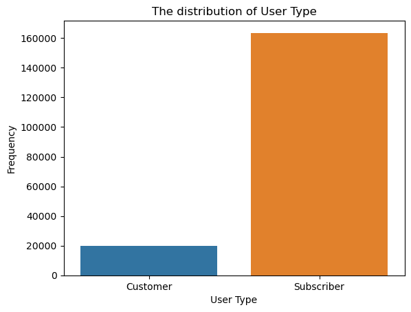

```python
sns.countplot(data=df, x='user_type')
chart_labels('The distribution of User Type','User Type','Frequency')
```

**2. What is the distribtution of member age?**

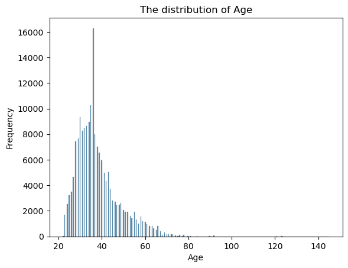

```python
sns.histplot(data=df, x='member_age')
chart_labels('The distribution of Age','Age','Frequency')
```

Most users are between 22 and 40 years old.

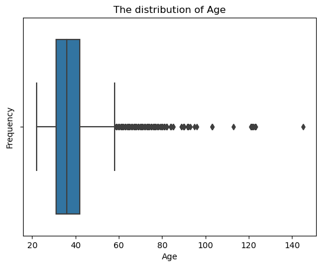

```python
#Use boxplot for describing outliers more clearly
sns.boxplot(data=df,x='member_age')
chart_labels('The distribution of Age','Age','Frequency')
```

The chart above shows that we got an outlier for the user's age, nearly 146 years old

**3. What is the distribution of duration in hours?**

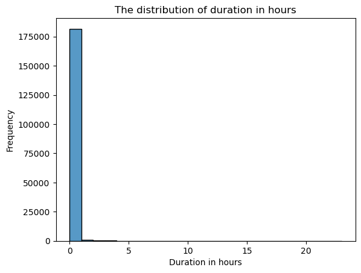

```python
bins = np.arange(0, df['duration_hour'].max())
sns.histplot(data=df, x='duration_hour',bins=bins)
chart_labels('The distribution of duration in hours','Duration in hours','Frequency')
```

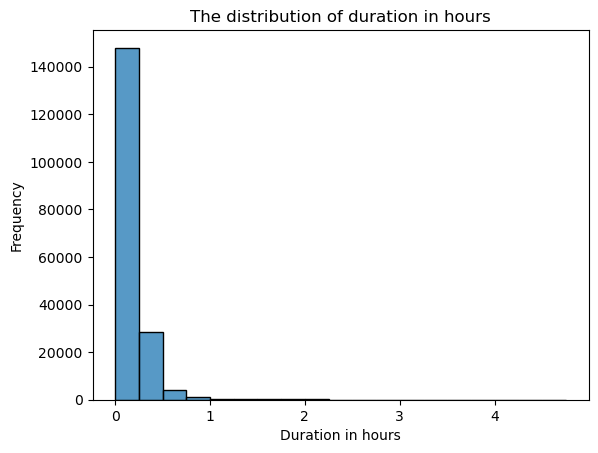

```python
#change the bins to focus the distribution form 0 - 5 hour
bins = np.arange(0, 5,0.25)
sns.histplot(data=df, x='duration_hour',bins=bins)
chart_labels('The distribution of duration in hours','Duration in hours','Frequency')
```

The chart above shows that the majority of the users trip for less than half an hour

**4. What is the distribution of member gender?**

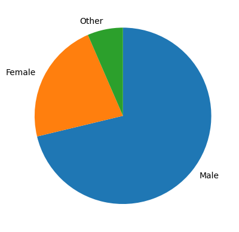

```python
gender_counts = df['member_gender'].value_counts()
gender_counts
plt.pie(gender_counts, labels = gender_counts.index, startangle = 90, counterclock = False);
```

In the pie chart, it is evident that the majority of users are male

### Discuss the distribution(s) of your variable(s) of interest. Were there any unusual points? Did you need to perform any transformations?

**Transformations:**

> - I need to calculate the age from "member_birth_year" field to analysis.
> - Calculate duration in hours based on "duration_sec".

**The distribution(s) of your variable(s)**

> - Most of the trips are less than 0.5 hour.
> - The majority of users are of the Subscriber type.
> - Most users are between 22 and 40 years old.
> - Most of users are Male.

### Of the features you investigated, were there any unusual distributions? Did you perform any operations on the data to tidy, adjust, or change the form of the data? If so, why did you do this?

> - We have age outliers for users older than 100 years, the boxplot can show that clearly.

## Bivariate Exploration

> In this section, investigate relationships between pairs of variables in your data. Make sure the variables that you cover here have been introduced in some fashion in the previous section (univariate exploration).

**1. Relationships between age and trip duration**

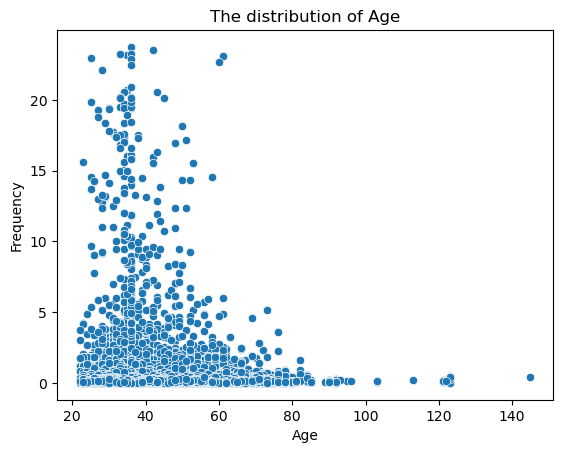

```python
sns.scatterplot(data=df, x='member_age', y='duration_hour');
chart_labels('The distribution of Age','Age','Frequency')
```

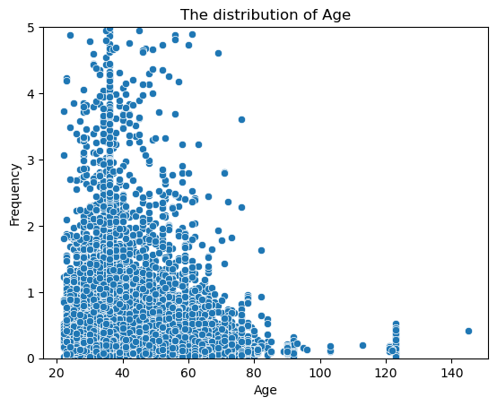

```python
#set ylim to zoom in the chart to range 0 - 5 hour
sns.scatterplot(data=df, x='member_age', y='duration_hour');
plt.ylim(0,5)
chart_labels('The distribution of Age','Age','Frequency')
```

Older member tend to take shorter trip.

**2. Relationships between user type and age**

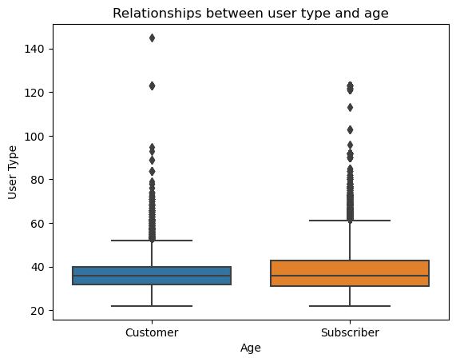

```python
sns.boxplot(data=df, x='user_type', y='member_age');
chart_labels('Relationships between user type and age','Age','User Type')
```

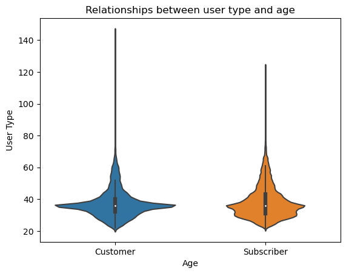

```python
# Utilize a violin chart for better clarity.
sns.violinplot(data=df, x='user_type', y='member_age');
chart_labels('Relationships between user type and age','Age','User Type')
```

The age distribution for "Customer" users has a higher concentration of users in the age range of 20 to 40 compared to "Subscriber" users.

**3. The relationship between User Type and Gender**

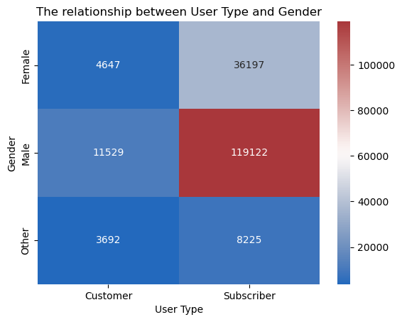

```python
df_pivoted = df.pivot_table('duration_hour', 'member_gender', 'user_type', aggfunc="count")

sns.heatmap(data=df_pivoted, annot=True, fmt=".0f", cmap='vlag')
chart_labels('The relationship between User Type and Gender','User Type','Gender')
```

A significant number of male subscribers exist.

### Talk about some of the relationships you observed in this part of the investigation. How did the feature(s) of interest vary with other features in the dataset?

> - Older member tend to take shorter trip.
> - The age distribution for "Customer" users has a higher concentration of users in the age range of 20 to 40 compared to "Subscriber" users
> - A significant number of male subscribers exist.

### Did you observe any interesting relationships between the other features (not the main feature(s) of interest)?

> Most users belong to the 'Subscriber' user type. However, it's worth noting that among 'Customer' users, a significant portion falls within the age range of 20-40 years old, and they tend to take longer trips.

## Multivariate Exploration

> Create plots of three or more variables to investigate your data even further. Make sure that your investigations are justified, and follow from your work in the previous sections.

**1. Daily Usage Per User Type and Gender**

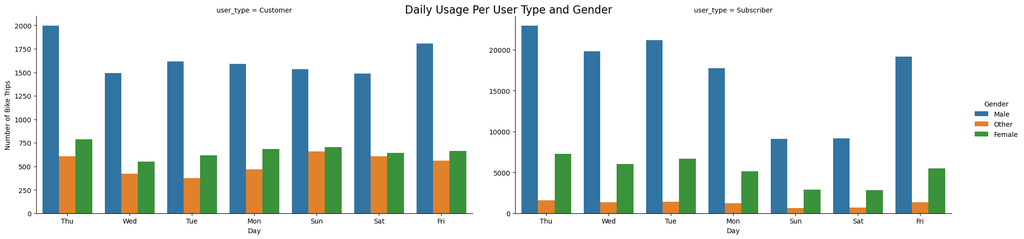

```python
# Daily usage - user type and gender
chart = sns.catplot(data=df, x='start_time_weekday', col='user_type', hue='member_gender', kind='count', sharey = False, height=5, aspect=2);
chart._legend.set_title('Gender')
chart.set_axis_labels('Day', 'Number of Bike Trips')
chart.fig.suptitle('Daily Usage Per User Type and Gender',fontsize=16)
```

The number of subscriber users is more than customer users. The number of records on Thursday is higher for both types compared to other days.

**2. User Type, Gender and Age**

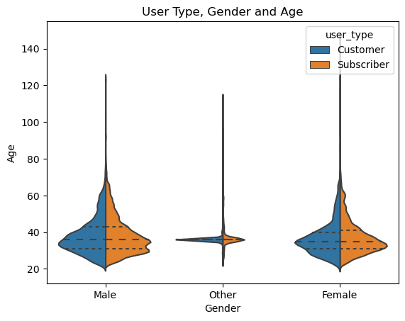

```python
sns.violinplot(data=df, x='member_gender', y='member_age', hue="user_type", split=True,  inner="quartile")
chart_labels('User Type, Gender and Age','Gender','Age')
```

It appears that both customers and subscribers share the same age range for both males and females.

**3. Duration Every Weekday Based on User Type**

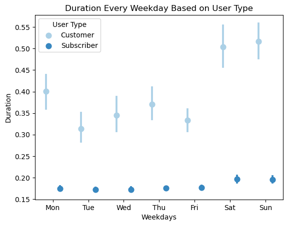

```python
weekdays = ['Mon', 'Tue', 'Wed', 'Thu', 'Fri', 'Sat', 'Sun']
sns.pointplot(data=df, x='start_time_weekday', y='duration_hour', hue='user_type',order=weekdays,
              palette = 'Blues', linestyles='', dodge=0.4)
plt.legend(title='User Type');
chart_labels('Duration Every Weekday Based on User Type','Weekdays','Duration')
```

Customer users tend to take longer trips than Subscriber users. Users tend to take longer trips on Saturdays and Sundays.

### Talk about some of the relationships you observed in this part of the investigation. Were there features that strengthened each other in terms of looking at your feature(s) of interest?

> - The number of subscriber users is more than customer users. The number of records on Thursday is higher for both types compared to other days.
> - Customer users tend to take longer trips than Subscriber users. Users tend to take longer trips on Saturdays and Sundays.

## Conclusions

> - Older member tend to take shorter trip.
> - The age distribution for "Customer" users has a higher concentration of users in the age range of 20 to 40 compared to "Subscriber" users
> - A significant number of male subscribers exist.
> - Customer users tend to take longer trips than Subscriber users. Users tend to take longer trips on Saturdays and Sundays.